← Back to ML Fundamentals • Week 9 of 0–15

# Week 9 — ML Fundamentals

[Open in Colab](https://colab.research.google.com/github/sanketn26/learn-ml/blob/main/notebooks/week-09-saas.ipynb) [Open in VS Code](https://vscode.dev/github/sanketn26/learn-ml/blob/main/notebooks/week-09-saas.ipynb) Open in Jupyter [Download .ipynb](https://raw.githubusercontent.com/sanketn26/learn-ml/main/notebooks/week-09-saas.ipynb)

### 📝 How to Run This Notebook Locally

**1. Clone the repository:**  
`git clone https://github.com/sanketn26/learn-ml.git && cd learn-ml`

**2. Set up environment:**  
`python3 -m venv venv && source venv/bin/activate`  
`pip install jupyter notebook`

**3. Install course dependencies:**  
`pip install numpy pandas scikit-learn matplotlib scipy seaborn`  
`pip install torch`

**4. Open the notebook:**  
`jupyter notebook notebooks/week-09-saas.ipynb`

# Week 9 — PCA: JPEG for Tables

**Course:** Applied ML Foundations for SaaS Analytics  
**Who this is for:** Engineers who have compressed images or used `SELECT` a subset of columns because 200 of them were correlated.

## 🎯 What you will be able to do

- Picture PCA as **rotating the cloud** so the first axis points along the stretch
- Read a scree plot: “how many axes until the leftover is noise?”
- Use 2-D PCA as a map, not as a causal feature named “growth”
- Spot odd customers via reconstruction error
- Know when *not* to bother (we only have a handful of columns)

**Think of it like… photographing a dinner plate from above vs from the edge.**

The plate is 3-D. From the edge it looks like a line — you lost the interesting shape. From above you kept the wide part. PCA finds the “from above” angles automatically: the directions where customers differ the most.

Or: **JPEG for a table**. Keep the big blobs of ink, drop the speckle. You cannot read a pixel-perfect original, but you can still tell it is a face (or a whale customer).

```python
%matplotlib inline
from pathlib import Path
import sys

import numpy as np
import pandas as pd
import matplotlib.pyplot as plt

# Make the shared style kit importable whether you launch from notebooks/ or repo root
for _p in [Path.cwd(), Path.cwd() / "notebooks", Path.cwd().parent]:
    if (_p / "course_style.py").exists():
        sys.path.insert(0, str(_p))
        break

from course_style import apply_style, setup_plots, find_data_dir

apply_style()
setup_plots()
DATA = find_data_dir()
print(f"Data folder: {DATA}")
print("Laptop mode: no GPU required. Models use a sample so each week finishes in a few minutes on CPU.")

from sklearn.preprocessing import StandardScaler
from sklearn.decomposition import PCA
```

```
Data folder: /Users/sanketnaik/workspace/learn-ml/data
Laptop mode: no GPU required. Models use a sample so each week finishes in a few minutes on CPU.
```

## Honesty first: the “curse of dimensionality”

Textbooks scare you with 10,000 columns. CloudWave’s customer table has ~7 numeric fields. PCA will still **draw a useful map**. It will not demonstrate the curse. If you one-hot 200 countries + 500 feature flags, *then* distances die and k-NN / K-Means get dizzy. That is the curse: in high dimensions everyone is far from everyone, so “nearest” stops meaning “similar.”

**Engineer mental model**

[output not shown]

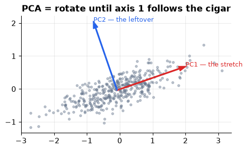

```python
from course_style import load_customer_360

df = load_customer_360(DATA)
cols = ["mrr", "tenure_days", "log_usage", "features_adopted", "total_events", "avg_session", "n_support"]
sample = df.sample(6000, random_state=0)
X = StandardScaler().fit_transform(sample[cols])

# Cartoon: a diagonal cloud, then the axes PCA would pick
rng = np.random.default_rng(1)
t = rng.normal(size=400)
cloud = np.c_[t, 0.3 * t + rng.normal(scale=0.25, size=400)]
pca_c = PCA(n_components=2).fit(cloud)

fig, ax = plt.subplots(figsize=(5.2, 4.2))
ax.scatter(cloud[:, 0], cloud[:, 1], s=10, alpha=0.4, c="#64748b")
origin = pca_c.mean_
for vec, name, color in zip(pca_c.components_, ["PC1 — the stretch", "PC2 — the leftover"],
                            ["#dc2626", "#2563eb"]):
    ax.arrow(*origin, *(vec * 2), color=color, width=0.03, head_width=0.15)
    ax.text(*(origin + vec * 2.2), name, color=color, fontsize=9)
ax.set_title("PCA = rotate until axis 1 follows the cigar")
ax.set_aspect("equal")
plt.tight_layout()
plt.show()
```

## Scree plot + a 2-D map of CloudWave

**Math, translated**

**Explained variance ratio** = “what fraction of the total stretch lives on this axis?” If PC1+PC2 hold 70%, a 2-D scatter still looks like the data. If they hold 20%, you flattened a ball into a pancake and lost the plot.

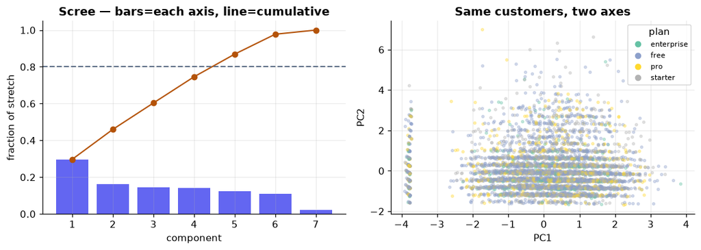

```
Variance kept by first 2 / 3 components: 46% / 60%
```

```python
pca = PCA().fit(X)
evr = pca.explained_variance_ratio_

fig, axes = plt.subplots(1, 2, figsize=(11, 4))
axes[0].bar(range(1, len(evr) + 1), evr, color="#6366f1")
axes[0].plot(range(1, len(evr) + 1), np.cumsum(evr), marker="o", color="#b45309")
axes[0].axhline(0.8, ls="--", color="#64748b")
axes[0].set_xlabel("component")
axes[0].set_ylabel("fraction of stretch")
axes[0].set_title("Scree — bars=each axis, line=cumulative")

xy = PCA(n_components=2).fit_transform(X)
plan_codes = sample["plan_type"].astype("category")
scatter = axes[1].scatter(xy[:, 0], xy[:, 1], s=8, alpha=0.35, c=plan_codes.cat.codes, cmap="Set2")
handles = [plt.Line2D([0], [0], marker="o", ls="", color=plt.cm.Set2(i / max(len(plan_codes.cat.categories)-1, 1)),
                      label=cat) for i, cat in enumerate(plan_codes.cat.categories)]
axes[1].legend(handles=handles, title="plan", fontsize=8)
axes[1].set_xlabel("PC1"); axes[1].set_ylabel("PC2")
axes[1].set_title("Same customers, two axes")
plt.tight_layout()
plt.show()

print("Variance kept by first 2 / 3 components:",
      f"{evr[:2].sum():.0%} / {evr[:3].sum():.0%}")
```

## Loadings — what *is* PC1 in English?

A **loading** is how much each original column leans on that axis. Large absolute loading → that column is a big ingredient of the axis.

```python
loadings = pd.DataFrame(pca.components_[:3].T, index=cols, columns=["PC1", "PC2", "PC3"])
print(loadings.round(2).to_string())
print("\nRead the biggest numbers in PC1 and name it in a Slack message.")

# Reconstruction error as 'does not fit the usual recipe'
pca3 = PCA(n_components=3).fit(X)
recon = pca3.inverse_transform(pca3.transform(X))
err = ((X - recon) ** 2).sum(axis=1)
sample = sample.copy()
sample["recon_error"] = err
print("\nOddballs (high reconstruction error):")
print(sample.nlargest(8, "recon_error")[["user_id", "plan_type", "mrr", "total_usage", "recon_error"]].to_string(index=False))
```

```
                   PC1   PC2   PC3
mrr              -0.00 -0.01  0.71
tenure_days      -0.02  0.03 -0.70
log_usage         0.65 -0.01 -0.01
features_adopted  0.62 -0.02 -0.01
total_events     -0.00  0.71  0.00
avg_session       0.44  0.04 -0.01
n_support         0.01  0.71  0.04

Read the biggest numbers in PC1 and name it in a Slack message.

Oddballs (high reconstruction error):
    user_id  plan_type    mrr  total_usage  recon_error
user_032055 enterprise 479.56         11.0    45.633433
user_004132       free   0.00          6.0    44.707432
user_035658       free   0.00          2.0    35.468521
user_037763 enterprise 453.21         11.0    33.823877
user_025185    starter  28.49          4.0    31.411047
user_017584        pro 104.00         10.0    31.332397
user_050454 enterprise 477.93          8.0    31.233178
user_010371 enterprise 505.85         10.0    28.695526
```

**Watch out**

PCA axes are not causes. An anomaly is “does not compress well,” which might be a new customer type, a data bug, or a whale. Do not auto-ban them.

**Ship / don’t ship**

Use PCA to *look* and to compress a wide one-hot jungle before k-NN. Prefer original columns for a churn model you have to explain. Skip the autoencoder / t-SNE flex until you have a picture PCA cannot draw.

## ✍️ Exercises

**1. Color by churn.** Same 2-D scatter, color = `is_churned`. Do churners own a corner, or are they sprinkled?

**2. How many components?** Pick the smallest k with cumulative variance ≥ 80%. Rebuild the oddball list. Do the same user ids show up?

**3. Do not ship PC3.** Write the one-sentence Slack message you would send instead of “PC3 is important.”

## 🤔 Reflection

1. Why did we scale before PCA? (Otherwise MRR, in dollars, owns the first axis.)
2. If two columns are almost the same (usage and events), what should PC1 do?
3. When is “we reduced to 2-D” a vanity metric?

## 🔗 Next week

Committees of models. Bagging vs boosting — a room of reviewers vs a sequence of specialists hunting the last miss.

← Previous Week Back to ML Fundamentals Next Week →